# Tugas Praktikum MPDW Pertemuan 7

2023-09-30

## Packages

```r
library(ggplot2)
library(tsibble)
library(tseries)
library(MASS)
library(forecast)
library(TSA)
library(TTR)
library(aTSA)
library(graphics)
```

## Data Asli

Digunakan data Emisi CO2 di Dunia Sektor Industri dalam kurun waktu 1 Juni 2022 sampai 31 Mei 2023

```r
data<-rio::import("https://raw.githubusercontent.com/farhanabdillahh/PraktikumMPDW/main/data/datasetmpdw.csv")
data<-ts(data$value)
str(data)
```

```
##  Time-Series [1:365] from 1 to 365: 31.6 31.5 30.5 29.3 29.1 ...
```

### Eksplorasi Data

#### Plot Data Penuh

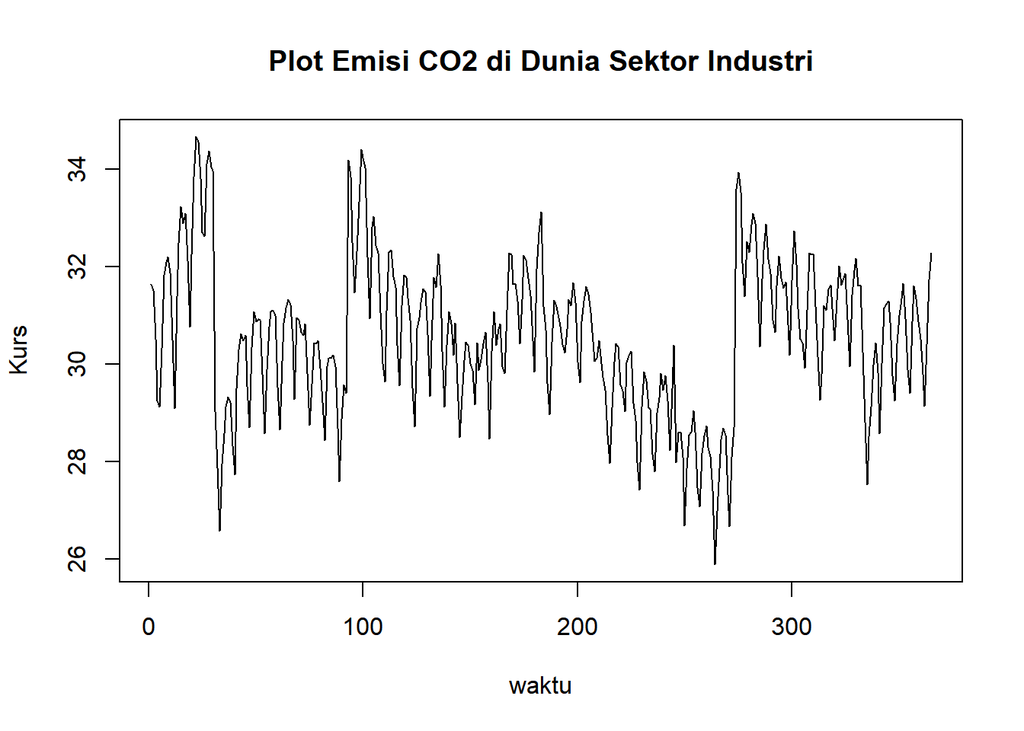

```r
plot.ts(data, lty=1, xlab="waktu", ylab="Kurs", main="Plot Emisi CO2 di Dunia Sektor Industri")
```

Berdasarkan plot data deret waktu, terlihat bahwa data cenderung memiliki trend yang naik turun. Berdasarkan pola data, pembagian data latih dan data uji ditetapkan dengan proporsi 74%:26%.

#### Plot Data Latih

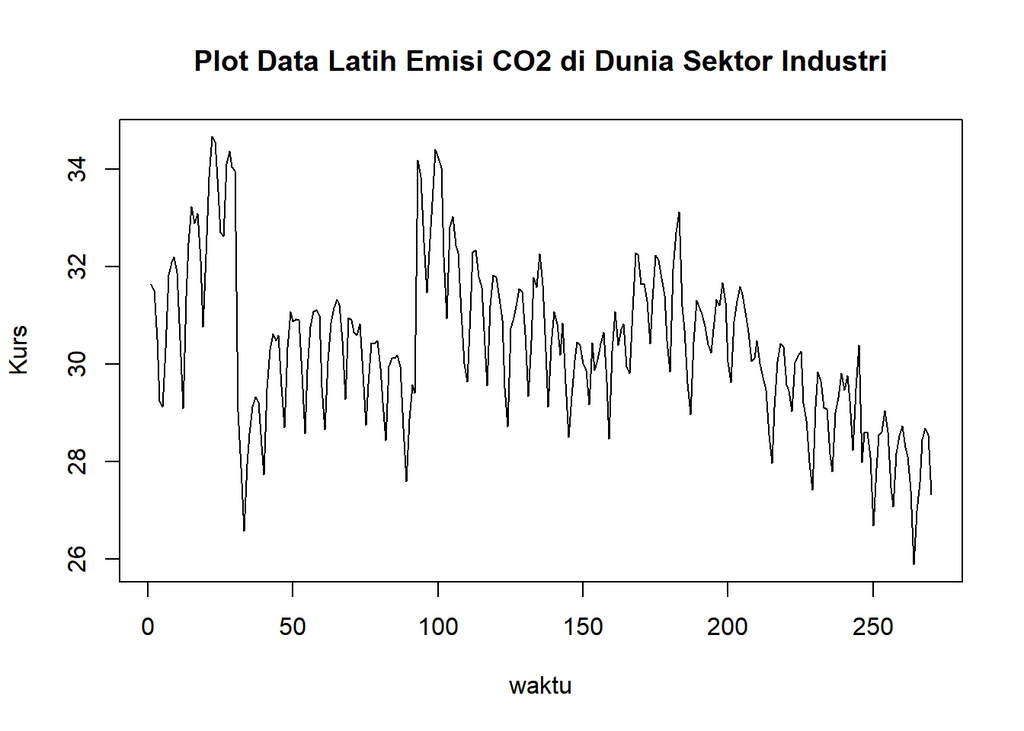

```r
kurstrain<-data[1:270]
train.ts<-ts(kurstrain)
plot.ts(train.ts, lty=1, xlab="waktu", ylab="Kurs", main="Plot Data Latih Emisi CO2 di Dunia Sektor Industri")
```

#### Plot Data Uji

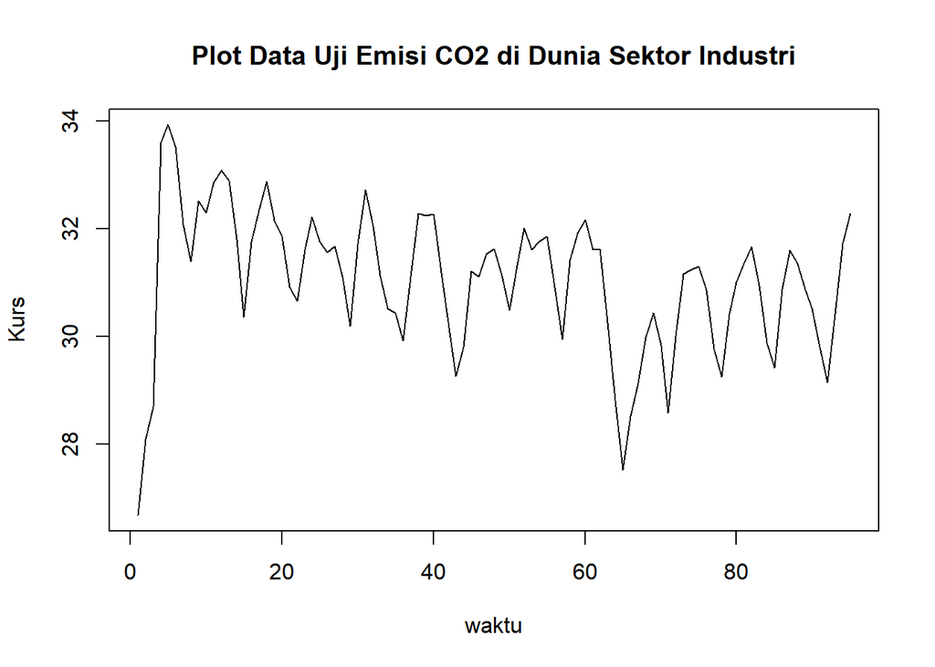

```r
kurstest<-data[271:365]
test.ts<-ts(kurstest)
plot.ts(test.ts, lty=1, xlab="waktu", ylab="Kurs", main="Plot Data Uji Emisi CO2 di Dunia Sektor Industri")
```

### Uji Stasioneritas Data

#### Plot ACF

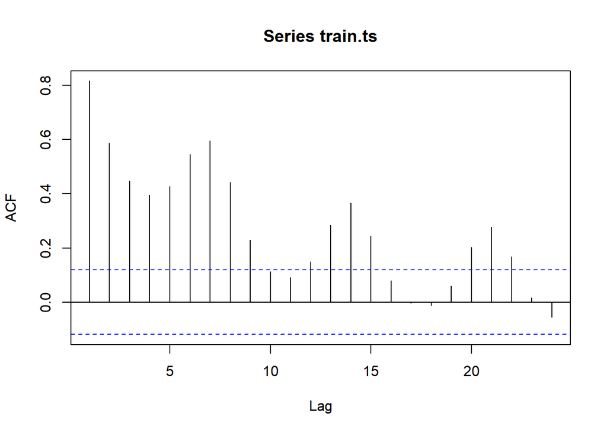

```r
acf(train.ts)
```

Berdasarkan plot ACF, terlihat bahwa plot ACF data menurun secara perlahan dan membentuk grafik sinus. Hal ini juga menjadi indikasi bahwa data tidak stasioner dalam rataan

#### Uji ADF

```r
tseries::adf.test(train.ts)
```

```
##
##  Augmented Dickey-Fuller Test
##
## data:  train.ts
## Dickey-Fuller = -2.4038, Lag order = 6, p-value = 0.4059
## alternative hypothesis: stationary
```

$H_0$ : Data tidak stasioner dalam rataan

$H_1$ : Data stasioner dalam rataan

Berdasarkan uji ADF tersebut, didapat *p-value* sebesar 0.4059 yang lebih besar dari taraf nyata 5% sehingga tak tolak $H_0$ dan menandakan bahwa data tidak stasioner dalam rataan. Hal ini sesuai dengan hasil eksplorasi menggunakan plot time series dan plot ACF, sehingga ketidakstasioneran model kedepannya harus ditangani

#### Plot Box-Cox

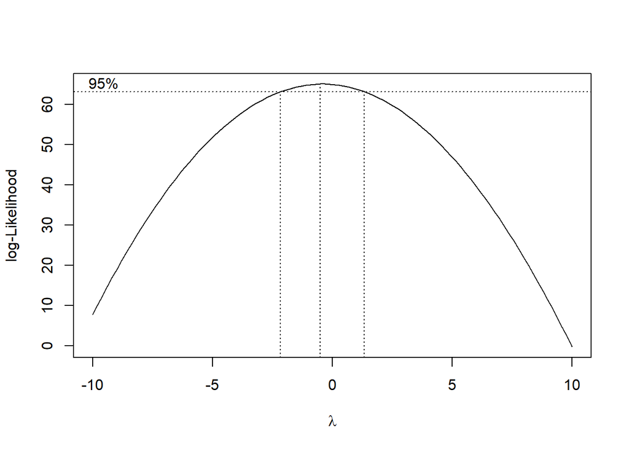

```r
index <- seq(1:270)
bc = boxcox(train.ts~index, lambda = seq(-10,10,by=1))
```

```r
#Nilai Rounded Lambda
lambda <- bc$x[which.max(bc$y)]
lambda
```

```
## [1] -0.5050505
```

```r
#SK
bc$x[bc$y > max(bc$y) - 1/2 * qchisq(.95,1)]
```

```
##  [1] -2.1212121 -1.9191919 -1.7171717 -1.5151515 -1.3131313 -1.1111111
##  [7] -0.9090909 -0.7070707 -0.5050505 -0.3030303 -0.1010101  0.1010101
## [13]  0.3030303  0.5050505  0.7070707  0.9090909  1.1111111  1.3131313
```

Plot Boxcox menunjukkan nilai *rounded value* ($\lambda$) optimum sebesar **-0.5050505** dan pada selang kepercayaan 95% nilai memiliki batas bawah **-2.1212121** dan batas atas **1.3131313**. Selang tersebut memuat nilai satu sehingga dapat dikatakan bahwa data bangkitan stasioner dalam ragam.

### Penanganan Ketidakstasioneran Data

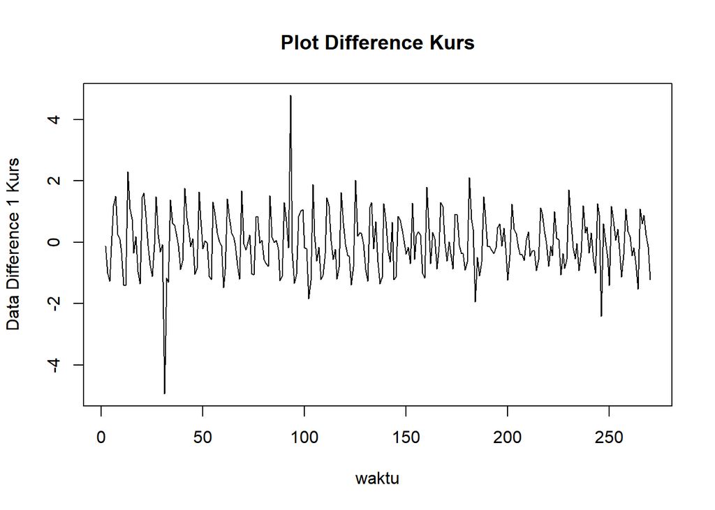

```r
train.diff<-diff(train.ts,differences = 1)
plot.ts(train.diff, lty=1, xlab="waktu", ylab="Data Difference 1 Kurs", main="Plot Difference Kurs")
```

Berdasarkan plot data deret waktu, terlihat bahwa data sudah stasioner dalam rataan ditandai dengan data bergerak pada nilai tengah tertentu (tidak terdapat trend ataupun musiman pada data)

#### Plot ACF

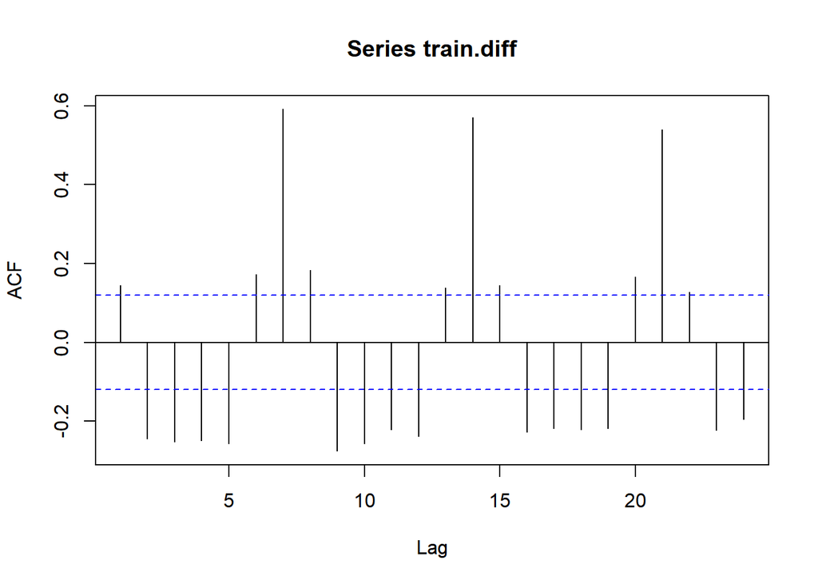

```r
acf(train.diff)
```

#### Uji ADF

```r
tseries::adf.test(train.diff)
```

```
##
##  Augmented Dickey-Fuller Test
##
## data:  train.diff
## Dickey-Fuller = -5.717, Lag order = 6, p-value = 0.01
## alternative hypothesis: stationary
```

$H_0$ : Data tidak stasioner dalam rataan

$H_1$ : Data stasioner dalam rataan

Berdasarkan uji ADF tersebut, didapat *p-value* sebesar 0.01 yang lebih kecil dari taraf nyata 5% sehingga tolak $H_0$ atau data stasioner dalam rataan. Hal ini sesuai dengan hasil eksplorasi menggunakan plot time series dan plot ACF, sehingga dalam hal ini ketidakstasioneran data sudah berhasil ditangani dan dapat dilanjutkan ke pemodelan

### Identifikasi Model

#### Plot ACF

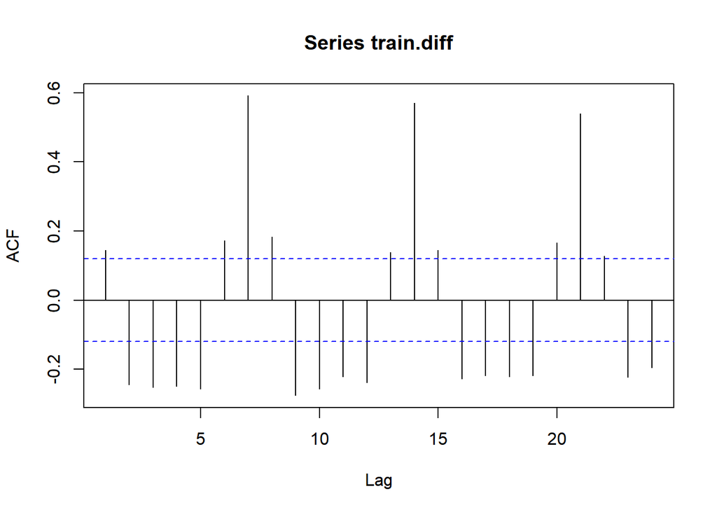

```r
acf(train.diff)
```

#### Plot PACF

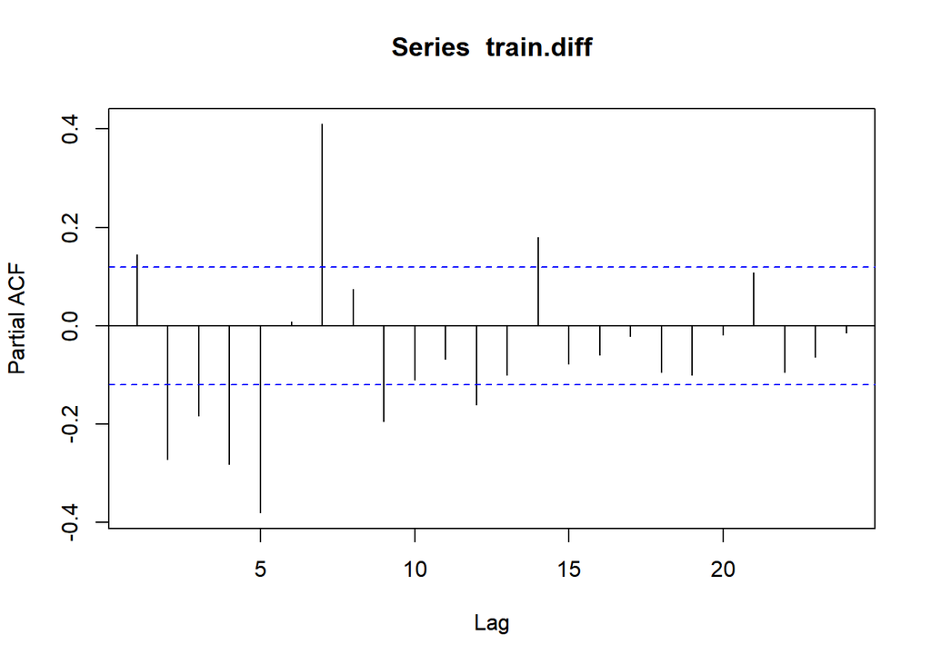

```r
pacf(train.diff)
```

#### Plot EACF

```r
eacf(train.diff)
```

```
## AR/MA
##   0 1 2 3 4 5 6 7 8 9 10 11 12 13
## 0 x x x x x x x x x x x  x  x  x
## 1 x x o o x o x x x o o  x  o  x
## 2 x x x o x o x o x o o  o  o  x
## 3 x x o o o o x o x o o  o  o  x
## 4 x o x o o o o o o o o  o  x  x
## 5 o x x o o x o o o o o  o  x  o
## 6 o x x x o x o o o o o  o  x  o
## 7 x x o x o x x o o o o  o  o  o
```

Identifikasi model menggunakan plot EACF dilakukan dengan melihat ujung segitiga pada pola segitiga nol. Dalam hal ini model tentatif yang terbentuk adalah ARIMA(2,1,9) ARIMA(4,1,5), ARIMA(4,1,6), ARIMA(4,1,7)

### Pendugaan Parameter Model Tentatif

#### ARIMA(0,1,1)

```r
model1.da=Arima(train.diff, order=c(0,1,1),method="ML")
summary(model1.da) #AIC=749.27
```

```
## Series: train.diff
## ARIMA(0,1,1)
##
## Coefficients:
##           ma1
##       -1.0000
## s.e.   0.0095
##
## sigma^2 = 0.9285:  log likelihood = -372.63
## AIC=749.27   AICc=749.31   BIC=756.45
##
## Training set error measures:
##                       ME      RMSE       MAE      MPE     MAPE      MASE
## Training set 0.001249883 0.9600084 0.7293074 97.26484 101.4413 0.8143376
##                   ACF1
## Training set 0.1468905
```

```r
lmtest::coeftest(model1.da) #seluruh parameter signifikan
```

```
##
## z test of coefficients:
##
##       Estimate Std. Error z value  Pr(>|z|)
## ma1 -0.9999951  0.0095287 -104.95 < 2.2e-16 ***
## ---
## Signif. codes:  0 '***' 0.001 '**' 0.01 '*' 0.05 '.' 0.1 ' ' 1
```

#### ARIMA(1,1,0)

```r
model2.da=Arima(train.diff, order=c(1,1,0),method="ML")
summary(model2.da) #AIC=866.2
```

```
## Series: train.diff
## ARIMA(1,1,0)
##
## Coefficients:
##           ar1
##       -0.2705
## s.e.   0.0588
##
## sigma^2 = 1.466:  log likelihood = -431.1
## AIC=866.2   AICc=866.25   BIC=873.38
##
## Training set error measures:
##                        ME     RMSE       MAE      MPE     MAPE      MASE
## Training set -0.003988287 1.206404 0.8649421 140.7484 269.9806 0.9657861
##                     ACF1
## Training set -0.08736101
```

```r
lmtest::coeftest(model2.da) #seluruh parameter signifikan
```

```
##
## z test of coefficients:
##
##      Estimate Std. Error z value  Pr(>|z|)
## ar1 -0.270470   0.058825 -4.5979 4.268e-06 ***
## ---
## Signif. codes:  0 '***' 0.001 '**' 0.01 '*' 0.05 '.' 0.1 ' ' 1
```

#### ARIMA(2,1,9)

```r
model3.da=Arima(train.diff, order=c(2,1,9),method="ML")
summary(model3.da) #AIC=643.92
```

```
## Series: train.diff
## ARIMA(2,1,9)
##
## Coefficients:
##           ar1      ar2      ma1     ma2      ma3      ma4     ma5     ma6
##       -0.4428  -0.9999  -0.4568  0.3840  -1.1829  -0.2777  0.0577  0.2451
## s.e.   0.0026   0.0003   0.0531  0.0601   0.0767   0.0865  0.0704  0.0869
##          ma7     ma8      ma9
##       0.2166  0.0948  -0.0770
## s.e.  0.0709  0.0575   0.0397
##
## sigma^2 = 0.581:  log likelihood = -309.96
## AIC=643.92   AICc=645.15   BIC=687.01
##
## Training set error measures:
##                       ME      RMSE       MAE      MPE     MAPE      MASE
## Training set -0.01965052 0.7450256 0.5337185 16.60491 166.4604 0.5959449
##                      ACF1
## Training set -0.004375566
```

```r
lmtest::coeftest(model3.da) #MA5, MA8, MA9 tidak signifikan
```

```
##
## z test of coefficients:
##
##       Estimate Std. Error    z value  Pr(>|z|)
## ar1 -0.4427987  0.0025933  -170.7472 < 2.2e-16 ***
## ar2 -0.9999328  0.0002793 -3580.1391 < 2.2e-16 ***
## ma1 -0.4568441  0.0530745    -8.6076 < 2.2e-16 ***
## ma2  0.3839585  0.0601152     6.3870 1.691e-10 ***
## ma3 -1.1829122  0.0767183   -15.4189 < 2.2e-16 ***
## ma4 -0.2776846  0.0864915    -3.2105  0.001325 **
## ma5  0.0577133  0.0703527     0.8203  0.412021
## ma6  0.2451377  0.0868932     2.8211  0.004785 **
## ma7  0.2166116  0.0709236     3.0542  0.002257 **
## ma8  0.0947569  0.0575235     1.6473  0.099502 .
## ma9 -0.0769913  0.0396554    -1.9415  0.052197 .
## ---
## Signif. codes:  0 '***' 0.001 '**' 0.01 '*' 0.05 '.' 0.1 ' ' 1
```

#### ARIMA(4,1,5)

```r
model4.da=Arima(train.diff, order=c(4,1,5),method="ML")
summary(model4.da) #640.52
```

```
## Series: train.diff
## ARIMA(4,1,5)
##
## Coefficients:
##           ar1      ar2      ar3      ar4      ma1      ma2     ma3     ma4
##       -0.3055  -0.0360  -0.3263  -0.9765  -0.7392  -0.3238  0.3238  0.7392
## s.e.   0.0238   0.0257   0.0228   0.0186   0.0324   0.0394  0.0403  0.0432
##           ma5
##       -1.0000
## s.e.   0.0395
##
## sigma^2 = 0.575:  log likelihood = -310.26
## AIC=640.52   AICc=641.38   BIC=676.43
##
## Training set error measures:
##                       ME      RMSE       MAE      MPE     MAPE      MASE
## Training set -0.01867206 0.7440812 0.5426224 94.85472 242.3401 0.6058869
##                    ACF1
## Training set -0.1108187
```

```r
lmtest::coeftest(model4.da) #ar2 tidak signifikan
```

```
##
## z test of coefficients:
##
##      Estimate Std. Error  z value  Pr(>|z|)
## ar1 -0.305452   0.023752 -12.8599 < 2.2e-16 ***
## ar2 -0.035994   0.025709  -1.4001    0.1615
## ar3 -0.326284   0.022807 -14.3060 < 2.2e-16 ***
## ar4 -0.976491   0.018634 -52.4038 < 2.2e-16 ***
## ma1 -0.739215   0.032432 -22.7925 < 2.2e-16 ***
## ma2 -0.323815   0.039423  -8.2138 < 2.2e-16 ***
## ma3  0.323815   0.040318   8.0315 9.632e-16 ***
## ma4  0.739212   0.043218  17.1042 < 2.2e-16 ***
## ma5 -0.999993   0.039530 -25.2971 < 2.2e-16 ***
## ---
## Signif. codes:  0 '***' 0.001 '**' 0.01 '*' 0.05 '.' 0.1 ' ' 1
```

#### ARIMA(4,1,6)

```r
model5.da=Arima(train.diff, order=c(4,1,6),method="ML")
summary(model5.da) #AIC=555.96
```

```
## Series: train.diff
## ARIMA(4,1,6)
##
## Coefficients:
##          ar1      ar2     ar3      ar4      ma1     ma2      ma3     ma4
##       0.8023  -1.4430  0.7985  -0.9969  -1.8819  2.3334  -2.3452  1.9007
## s.e.  0.0054   0.0075  0.0076   0.0041   0.0604  0.1097   0.1413  0.1475
##           ma5     ma6
##       -1.1022  0.0964
## s.e.   0.1183  0.0605
##
## sigma^2 = 0.4157:  log likelihood = -266.98
## AIC=555.96   AICc=556.99   BIC=595.46
##
## Training set error measures:
##                       ME      RMSE       MAE      MPE     MAPE      MASE
## Training set -0.02033339 0.6314093 0.4061536 20.56229 140.9618 0.4535072
##                     ACF1
## Training set -0.04268969
```

```r
lmtest::coeftest(model5.da) #ma6 tidak signifikan
```

```
##
## z test of coefficients:
##
##       Estimate Std. Error   z value Pr(>|z|)
## ar1  0.8023328  0.0053574  149.7605   <2e-16 ***
## ar2 -1.4429637  0.0075263 -191.7226   <2e-16 ***
## ar3  0.7985123  0.0075716  105.4613   <2e-16 ***
## ar4 -0.9968579  0.0040971 -243.3089   <2e-16 ***
## ma1 -1.8819248  0.0604140  -31.1505   <2e-16 ***
## ma2  2.3334073  0.1096624   21.2781   <2e-16 ***
## ma3 -2.3451704  0.1413315  -16.5934   <2e-16 ***
## ma4  1.9006674  0.1475477   12.8817   <2e-16 ***
## ma5 -1.1021772  0.1183097   -9.3160   <2e-16 ***
## ma6  0.0964340  0.0604860    1.5943   0.1109
## ---
## Signif. codes:  0 '***' 0.001 '**' 0.01 '*' 0.05 '.' 0.1 ' ' 1
```

#### ARIMA(4,1,7)

```r
model6.da=Arima(train.diff, order=c(4,1,7),method="ML")
summary(model6.da) #AIC=550.06
```

```
## Series: train.diff
## ARIMA(4,1,7)
##
## Coefficients:
##          ar1      ar2     ar3      ar4      ma1     ma2      ma3     ma4
##       0.8038  -1.4462  0.8046  -0.9981  -1.9160  2.4920  -2.6428  2.2328
## s.e.  0.0046   0.0041  0.0044   0.0025   0.0629  0.1303   0.1840  0.2060
##           ma5     ma6      ma7
##       -1.3662  0.2827  -0.0823
## s.e.   0.1865  0.1369   0.0672
##
## sigma^2 = 0.4048:  log likelihood = -263.03
## AIC=550.06   AICc=551.28   BIC=593.15
##
## Training set error measures:
##                       ME      RMSE       MAE      MPE     MAPE      MASE
## Training set -0.01494338 0.6218687 0.4075655 18.09665 144.0409 0.4550837
##                     ACF1
## Training set 0.005320525
```

```r
lmtest::coeftest(model6.da) #ma7 tidak signifikan
```

```
##
## z test of coefficients:
##
##       Estimate Std. Error   z value  Pr(>|z|)
## ar1  0.8037840  0.0046077  174.4442 < 2.2e-16 ***
## ar2 -1.4461729  0.0041471 -348.7167 < 2.2e-16 ***
## ar3  0.8045542  0.0044313  181.5616 < 2.2e-16 ***
## ar4 -0.9980640  0.0024562 -406.3416 < 2.2e-16 ***
## ma1 -1.9160331  0.0628903  -30.4663 < 2.2e-16 ***
## ma2  2.4920157  0.1303272   19.1212 < 2.2e-16 ***
## ma3 -2.6428209  0.1839782  -14.3649 < 2.2e-16 ***
## ma4  2.2328412  0.2060054   10.8388 < 2.2e-16 ***
## ma5 -1.3661589  0.1864923   -7.3256 2.379e-13 ***
## ma6  0.2826503  0.1368996    2.0647   0.03896 *
## ma7 -0.0823307  0.0672030   -1.2251   0.22054
## ---
## Signif. codes:  0 '***' 0.001 '**' 0.01 '*' 0.05 '.' 0.1 ' ' 1
```

```r
# Membuat vektor yang berisi nama model
model_names <- c("model1.da", "model2.da", "model3.da", "model4.da", "model5.da", "model6.da")

get_aic <- function(model) {
  return(AIC(model))
}

result <- data.frame()

for (i in model_names) {
  model <- get(i)
    aic <- get_aic(model)
    result <- rbind(result, aic)
}
colnames(result) <- "AIC"
rownames(result) <- model_names
result
```

```
##                AIC
## model1.da 749.2667
## model2.da 866.2025
## model3.da 643.9216
## model4.da 640.5231
## model5.da 555.9555
## model6.da 550.0607
```

Berdasarkan pendugaan parameter di atas, nilai AIC terkecil dimiliki oleh model ARIMA(4,1,7) tetapi terdapat parameter yg tidak signifikan. Oleh karena itu, model ini dipilih diantara ARIMA(0,1,1) dan ARIMA(1,1,0) karena kedua model tersebut keseluruhan parameternya signifikan. Model yang dipilih adalah AIC terkecil dan seluruh parameter signifikan. Oleh karena itu, yang dipilih adalah ARIMA(0,1,1)